# Concession Promotion Impact & Cannibalization — 300 Level Only

- Show All Code
- Hide All Code
- View Source

Do the Miller High Life and 6-1 hot dog promotions grow sales, or just shift them, at the level where they actually ran?

Published

August 25, 2026

**ImportantBottom line**

**At the 300 level — where these promotions actually ran — Miller High Life shows a strong lift of +37% per fan (p < 0.001), and the within-game mix-shift toward the featured items is large and highly significant.**

- **Beer:** Within the same game, substitutes sell at only 0.68x the rate of Miller High Life (p < 0.001). The domestic-light beer group as a whole (+1.5%, p = 0.782) does not show a statistically confirmed decline, suggesting the promotion may be growing beer sales at the 300 level rather than simply reshuffling them.
- **Hot dogs:** Hot Dog 6-1 shows no reliable change at the 300 level (+6.7%, p = 0.410), consistent with the ballpark-wide finding.

# 1 Why we ran this version

The main cannibalization analysis looked at sales **ballpark-wide** — but the Miller High Life and Hot Dog 6-1 promotions were only actually stocked and served at **300-level stands**. Diluting the comparison across every stand in the ballpark risks understating the true size of any cannibalization effect at the stands where it matters. This version repeats the same four-method framework, restricted to item sales at 300-level stands only.

Promotions covered. Beer promotions = all three; hot dog promotions = Slide into Summer and Spring Value Games.

| Promotion | Window | Discounts | Game tiers |
| --- | --- | --- | --- |
| Slide into Summer (2025) | 5/30 to 6/05 | $2 6-1 hot dogs, $4 Miller High Life 12oz | 0, 1, 3, 4 |
| Spring Value Games (2026) | 3/30-4/01, 4/13-4/15, 4/28 | $2.50 6-1 hot dogs, $4 Miller High Life 12oz | 5 |
| May in the A (2026) | 5/12-5/14, 5/17, 5/22, 5/24 | $3 Miller High Life 12oz, $2 ice cream sandwiches | 2, 3 |

# 2 What we measured, and how

The three methods used in this 300-level view. Method D (Market-stand traffic) is not repeated here — see the main ballpark-wide report.

| Method | Plain-English question | How confounding is handled |
| --- | --- | --- |
| A. Category and family growth | Did total 300-level beer / hot dog sales (and close substitutes) go up or down per fan? | Matched on game tier, then re-checked against non-promo games from the same part of the season |
| B. Within-game comparison | Within the same game, did the featured item pull ahead of its close substitutes at the 300 level? | Compares items inside the same game, so crowd size, weather, and opponent cancel out |
| C. Item-by-item | Which specific 300-level items moved, and is it statistically real? | Same two lenses; corrected for testing many items at once |

A few choices worth knowing:

- **Everything is measured per fan** (per turnstile entry), so a busier or quieter night does not by itself look like a promotion effect.
- **We look at every across-game result two ways.** A *simple comparison* matches only on game tier. A *season-matched* comparison additionally restricts to non-promotion games from a similar time of year, since these promotions all run in spring. When the two lenses disagree, we rely on the season-matched result.
- **Close substitutes, not the whole menu.** Same substitute families as the ballpark-wide report — other domestic and light beers for Miller High Life, other hot dog sizes and adjacent entrees/snacks (burger basket, chicken tender basket, nachos, jumbo pretzel) for the 6-1 — restricted here to sales recorded at 300-level stands.

Items grouped into families, 300-level sales only. ‘contrast’ items are shown for reference only and are not counted as substitutes.

| Category | Family | Items |
| --- | --- | --- |
| Beer | beer_domestic_sub | Coors Banquet 16oz, Coors Light 16oz, Miller Lite 16oz |
| Beer | beer_largepour_sub | Coors Light 24oz, Miller Lite 24oz |
| Beer | beer_promoted | Miller High Life 12oz |
| Beer | contrast | Blue Moon 16oz, Leinenkugel Summer Shandy 16oz, Sweetwater Atlanta OG 16oz |
| Food | contrast | Pizza Pepperoni Slice 18 |
| Food | food_adjacent_entree_sub | Burger Basket, Chicken Tender Basket |
| Food | food_adjacent_snack_sub | Colossal Bavarian Pretzel, Pretzel Jumbo, Snack Nachos Classic |
| Food | food_hotdog_sub | Hot Dog All Beef 2-1, Hot Dog All Beef 4-1 |
| Food | food_promoted | Hot Dog All Beef 6-1 |

## 2.1 Data and its limits

Data used for this 300-level cut.

| Source | Level of detail |
| --- | --- |
| Item + transaction-level sales, 2025-26 | Every item sold, joined to transaction records to identify the serving stand and floor |
| Stand floor/level lookup | Maps each stand’s cost center to a physical concourse level |
| Concession KPIs | Attendance (turnstile) and promotion flags per game |
| Schedule | Game tier, day, weekend, opponent, time of year |

This view uses a different, more granular data source than the main report — item-level transaction data joined to a stand/floor lookup, rather than the ballpark-wide item-level export. It is restricted to stands identified as 300 level. Method D (Market-stand traffic) is not repeated here, since that method was already stand-specific in the main report.

Completeness of the 300-level item-by-game table.

| Category | Item-game rows | Filled-in zeros | % filled |
| --- | --- | --- | --- |
| Beer | 1458 | 2 | 0.1 |
| Food | 1782 | 5 | 0.3 |

# 3 What we found

## 3.1 Did the category grow, or did comparable items shrink?

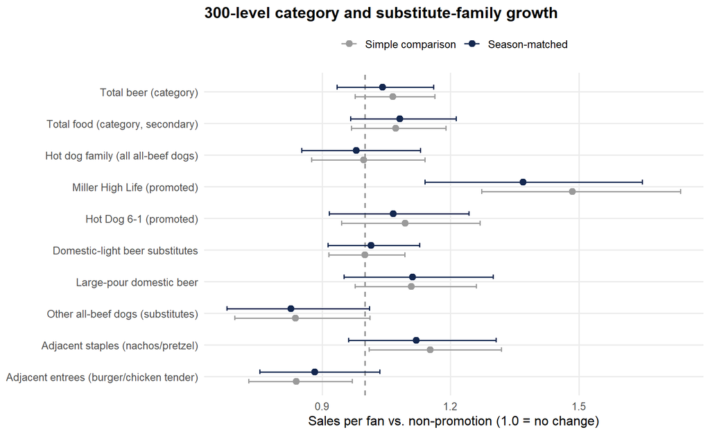

Figure 1: Change in 300-level sales per fan on promotion days, by group. Grey = simple comparison, navy = season-matched. Bars are 95% confidence ranges; dashed line at 1.0 = no change.

```r
gr %>%
  mutate(label = factor(label, levels = rev(unique(gr$label[order(gr$kind)]))),
         lens = factor(lens_label[model], levels = c("Simple comparison", "Season-matched"))) %>%
  ggplot(aes(rate_ratio, label, color = lens)) +
  geom_vline(xintercept = 1, linetype = "dashed", color = "grey50") +
  geom_errorbar(aes(xmin = ci_low, xmax = ci_high), orientation = "y",
                width = 0.3, position = position_dodge(width = 0.6)) +
  geom_point(size = 2.4, position = position_dodge(width = 0.6)) +
  scale_color_manual(values = pal_lens, name = NULL) +
  labs(x = "Sales per fan vs. non-promotion (1.0 = no change)", y = NULL,
       title = "300-level category and substitute-family growth")
```

300-level sales per fan on promotion vs. non-promotion days. 19 beer promotion games, 13 hot dog promotion games.

| Group | Type | Lens | Change per fan | 95% range | p-value |
| --- | --- | --- | --- | --- | --- |
| Total beer (category) | category | Simple comparison | +6.6% | 0.98 to 1.16 | 0.151 |
| Total beer (category) | category | Season-matched | +4.1% | 0.94 to 1.16 | 0.460 |
| Domestic-light beer substitutes | substitute | Simple comparison | -0.0% | 0.92 to 1.09 | 0.995 |
| Domestic-light beer substitutes | substitute | Season-matched | +1.5% | 0.91 to 1.13 | 0.782 |
| Large-pour domestic beer | substitute | Simple comparison | +10.9% | 0.98 to 1.26 | 0.111 |
| Large-pour domestic beer | substitute | Season-matched | +11.1% | 0.95 to 1.30 | 0.186 |
| Miller High Life (promoted) | promoted | Simple comparison | +48.4% | 1.27 to 1.74 | < 0.001 |
| Miller High Life (promoted) | promoted | Season-matched | +36.9% | 1.14 to 1.65 | < 0.001 |
| Total food (category, secondary) | category | Simple comparison | +7.2% | 0.97 to 1.19 | 0.181 |
| Total food (category, secondary) | category | Season-matched | +8.2% | 0.97 to 1.21 | 0.172 |
| Hot dog family (all all-beef dogs) | category | Simple comparison | -0.3% | 0.87 to 1.14 | 0.970 |
| Hot dog family (all all-beef dogs) | category | Season-matched | -2.0% | 0.85 to 1.13 | 0.782 |
| Other all-beef dogs (substitutes) | substitute | Simple comparison | -16.2% | 0.70 to 1.01 | 0.060 |
| Other all-beef dogs (substitutes) | substitute | Season-matched | -17.3% | 0.68 to 1.01 | 0.060 |
| Adjacent staples (nachos/pretzel) | substitute | Simple comparison | +15.2% | 1.01 to 1.32 | 0.035 |
| Adjacent staples (nachos/pretzel) | substitute | Season-matched | +12.0% | 0.96 to 1.31 | 0.141 |
| Adjacent entrees (burger/chicken tender) | substitute | Simple comparison | -16.0% | 0.73 to 0.97 | 0.017 |
| Adjacent entrees (burger/chicken tender) | substitute | Season-matched | -11.7% | 0.75 to 1.03 | 0.122 |
| Hot Dog 6-1 (promoted) | promoted | Simple comparison | +9.4% | 0.94 to 1.27 | 0.235 |
| Hot Dog 6-1 (promoted) | promoted | Season-matched | +6.7% | 0.92 to 1.24 | 0.410 |

Total beer per fan is roughly flat season-matched (+4.1%, p = 0.460). The domestic-light beer substitute family shows +1.5% (p = 0.782). On the food side, no category or family shows a reliable change.

## 3.2 Within the same game, did the featured item pull ahead?

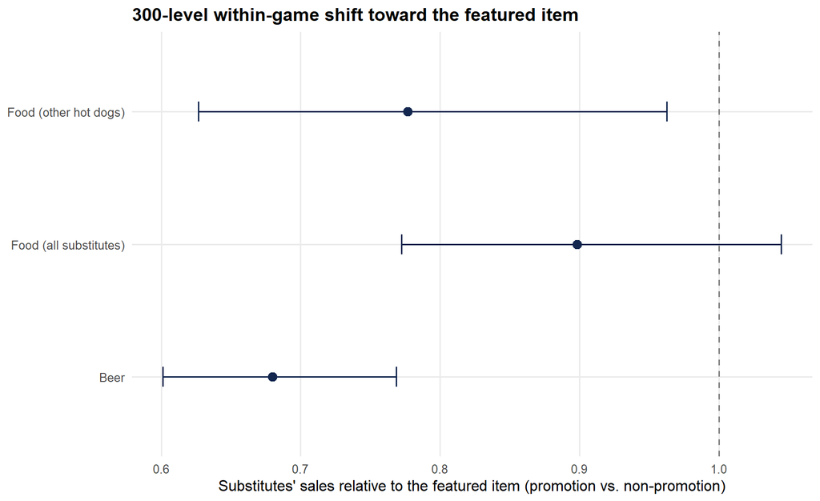

Figure 2: How close substitutes sold relative to the featured item at 300-level stands, within the same game. Below 1.0 means the mix shifted toward the featured item. Bars are 95% confidence ranges.

```r
wg %>% mutate(category = case_when(
    category == "food (all substitutes)" ~ "Food (all substitutes)",
    category == "food (other hot dogs)" ~ "Food (other hot dogs)",
    TRUE ~ str_to_title(category)
  )) %>%
  ggplot(aes(rel_rate_ratio, category)) +
  geom_vline(xintercept = 1, linetype = "dashed", color = "grey50") +
  geom_point(size = 3, color = "#13274F") +
  geom_errorbar(aes(xmin = ci_low, xmax = ci_high), width = 0.15, color = "#13274F") +
  labs(x = "Substitutes' sales relative to the featured item (promotion vs. non-promotion)", y = NULL,
       title = "300-level within-game shift toward the featured item")
```

300-level within-game shift toward the featured item.

| Category | Featured item | Games | Substitutes | Relative sales | 95% range | p-value |
| --- | --- | --- | --- | --- | --- | --- |
| Beer | Miller High Life 12oz | 162 | 5 | 0.680 | 0.60 to 0.77 | < 0.001 |
| Food (Other Hot Dogs) | Hot Dog All Beef 6-1 | 140 | 2 | 0.777 | 0.63 to 0.96 | 0.021 |
| Food (All Substitutes) | Hot Dog All Beef 6-1 | 140 | 7 | 0.898 | 0.77 to 1.04 | 0.164 |

Beer substitutes sell at only 0.68x Miller High Life’s rate within the same game (p < 0.001).

## 3.3 Item by item

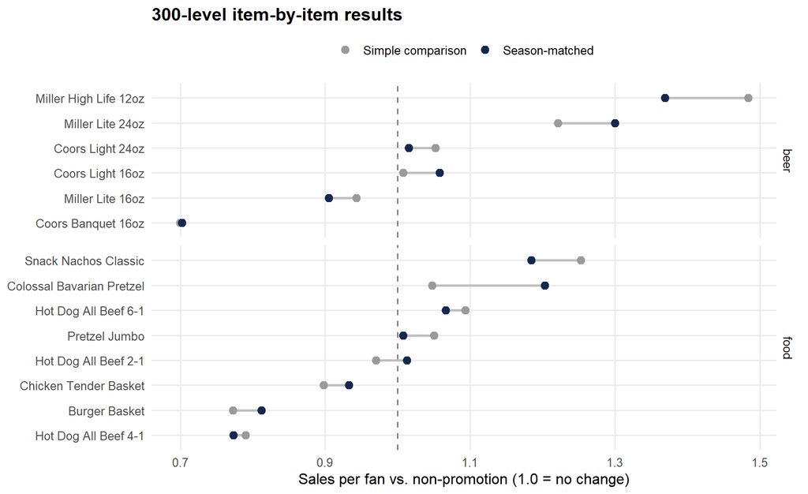

Figure 3: Each 300-level item’s sales change on promotion days: simple comparison (grey) vs. season-matched (navy). Featured and substitute items only. Dashed line at 1.0 = no change.

```r
ir %>% filter((is_substitute == 1 | is_promoted == 1), !is.na(rate_ratio), !is.na(rr_adj)) %>%
  select(name, category, tier = rate_ratio, adjusted = rr_adj) %>%
  pivot_longer(c(tier, adjusted), names_to = "model", values_to = "rr") %>%
  mutate(lens = factor(ifelse(model == "tier", "Simple comparison", "Season-matched"),
                       levels = c("Simple comparison", "Season-matched"))) %>%
  ggplot(aes(rr, reorder(name, rr))) +
  geom_vline(xintercept = 1, linetype = "dashed", color = "grey50") +
  geom_line(aes(group = name), color = "grey75", linewidth = 0.9) +
  geom_point(aes(color = lens), size = 2.6) +
  facet_grid(category ~ ., scales = "free_y", space = "free_y") +
  scale_color_manual(values = pal_lens, name = NULL) +
  labs(x = "Sales per fan vs. non-promotion (1.0 = no change)", y = NULL,
       title = "300-level item-by-item results")
```

300-level item-by-item change in sales per fan.

| Category | Item | Role | Simple % | Season-matched % | Season-matched p | Multi-test p |
| --- | --- | --- | --- | --- | --- | --- |
| Beer | Miller High Life 12oz | featured | +48.4% | +36.9% | < 0.001 | n/a |
| Beer | Coors Banquet 16oz | substitute | -30.1% | -29.8% | 0.024 | 0.095 |
| Beer | Miller Lite 24oz | substitute | +22.1% | +30.0% | 0.019 | 0.095 |
| Beer | Miller Lite 16oz | substitute | -5.7% | -9.5% | 0.251 | 0.488 |
| Beer | Coors Light 24oz | substitute | +5.2% | +1.6% | 0.928 | 0.949 |
| Beer | Coors Light 16oz | substitute | +0.7% | +5.8% | 0.730 | 0.949 |
| Food | Hot Dog All Beef 6-1 | featured | +9.4% | +6.7% | 0.410 | n/a |
| Food | Burger Basket | substitute | -22.8% | -18.8% | 0.036 | 0.107 |
| Food | Snack Nachos Classic | substitute | +25.3% | +18.5% | 0.089 | 0.215 |
| Food | Hot Dog All Beef 4-1 | substitute | -21.0% | -22.6% | 0.012 | 0.095 |
| Food | Chicken Tender Basket | substitute | -10.2% | -6.8% | 0.482 | 0.722 |
| Food | Pretzel Jumbo | substitute | +5.0% | +0.8% | 0.931 | 0.949 |
| Food | Colossal Bavarian Pretzel | substitute | +4.8% | +20.3% | 0.285 | 0.488 |
| Food | Hot Dog All Beef 2-1 | substitute | -3.0% | +1.3% | 0.949 | 0.949 |

### 3.3.1 Power

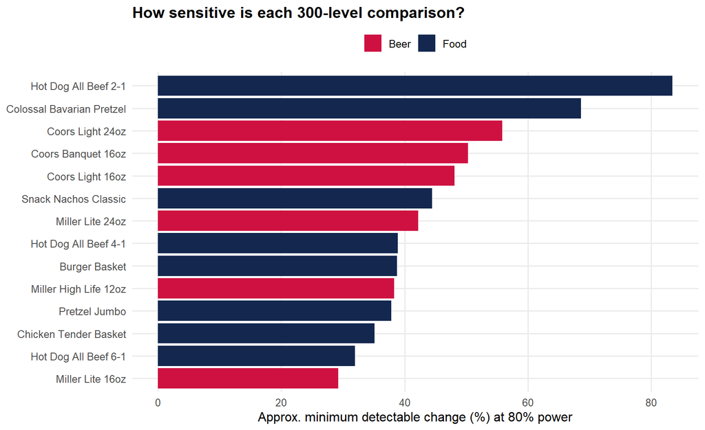

Figure 4: Approximate minimum detectable change (per fan, 80% power) per item, 300-level sales only. Large values mean a real moderate effect could go undetected.

```r
ir %>% filter(!is.na(mde_pct_80_approx), is_substitute == 1 | is_promoted == 1) %>%
  mutate(category = str_to_title(category)) %>%
  ggplot(aes(mde_pct_80_approx, reorder(name, mde_pct_80_approx), fill = category)) +
  geom_col() +
  scale_fill_manual(values = c("Beer" = "#CE1141", "Food" = "#13274F"), name = NULL) +
  labs(x = "Approx. minimum detectable change (%) at 80% power", y = NULL,
       title = "How sensitive is each 300-level comparison?")
```